## Research Internship - Summer 2021

## Data analysis for OSHA “Occupational Safety and Health Administration”

## Project Two:

### Does the involvement of union status increase or decreases the case duration to resolve? How long does it take for a union to resolve the issue?

## —————————————————————————————————

## Part One: Load packages and dataset

## —————————————————————————————————

## Part Two: About Variable

| VARIABLE NAME | DEFINTION | WHY IS THIS VARIABLE RELEVANT? WHAT DOES IT INDICATE? |
| --- | --- | --- |
| *union_present_sum.1* | *Presence of Union member during investigation* | *It is a better fit as it can indicate whether the presence of Union member helps to resolve violation investigation* |
| *case_days_open_sum.1* | *Total days used to resolve the case* | *It is a better fit as it can indicate how long it takes and how serious are the investigations* |
| *insp_scope_complete_sum.1* | *Total number of investigations that were Complete or Partial in scope* | *This can indicate if presence of union member makes the investigtion complete or leaves it partially* |
| *nr_instances_total.1* | *Total number of instances or times the violation was present* | *This can indicate as proxy for danger in the industry itself or hazard ignorance* |
| *total_exposed.1* | *Total number of people reported to be exposed from all violations cited* | *Individuals who are exposed from the hazardous substances can indicate a better fit because it determine how serious the violation was or not* |

```
##    CaseDuration Union InspectionScope NumberInstances PeopleExposure
## 1          5112     8               0               8              0
## 2            41     1               0               0              0
## 3            65     0               0               0              0
## 4         52903    39               0              59            685
## 5         13457    14               0              21           1136
## 6           175     1               0               0              0
## 7            86     0               0               0              0
## 8           124     1               0               0              0
## 9           143     1               0               0              0
## 10         2003     7               0               7              3
## 11          145     0               0               0              0
## 12          222     0               0               0              0
## 13         1005     3               0               3             46
## 14          646     2               0               2             97
## 15           41     0               0               0              0
## 16          111     0               0               0              0
## 17          186     1               0               5             21
## 18           14     1               0               0              0
## 19          172     1               0               0              0
## 20           97     0               0               0              0
```

## —————————————————————————————————

## Part Three: Approach using Multiple Regression Model

### a. Graphical representation and interpretation:

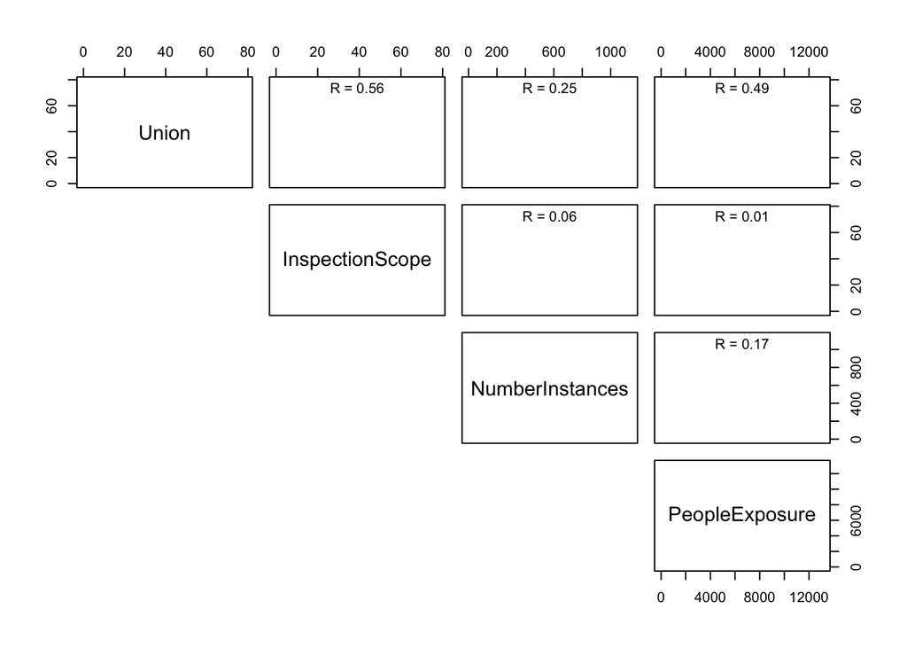

### b. Model building

```
##                      [,1]         [,2]
## (Intercept) -1415.2984115 5.406558e-02
## X1           1026.6958689 2.657880e-23
## X2           -809.9313669 1.285812e-09
## X3             -2.2662528 6.101533e-01
## X4             -0.6796899 2.571101e-01
```

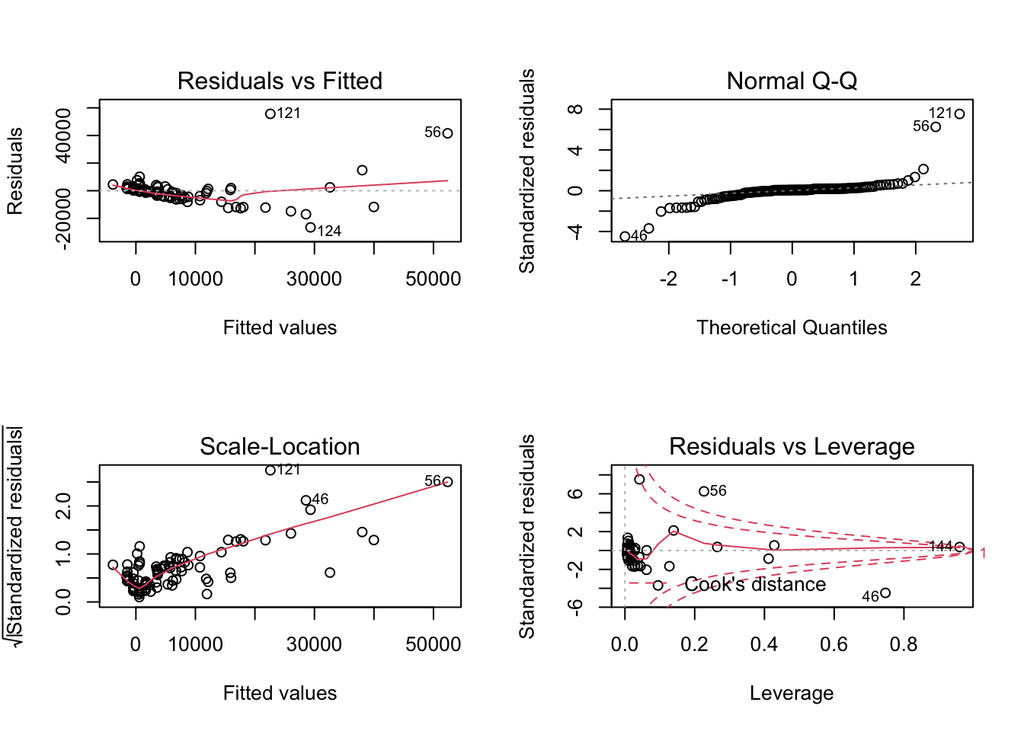

### 1. Check and Validate Assumption

```
##
## Call:
## lm(formula = log(Y + 1) ~ X1 + X2 + X3 + X4)
##
## Residuals:
##     Min      1Q  Median      3Q     Max
## -6.1811 -0.8168 -0.0917  1.2652  3.5563
##
## Coefficients:
##               Estimate Std. Error t value Pr(>|t|)
## (Intercept)  5.4017816  0.1667905  32.387  < 2e-16 ***
## X1           0.1612987  0.0196635   8.203 1.19e-13 ***
## X2          -0.1029569  0.0285584  -3.605 0.000429 ***
## X3           0.0006748  0.0010151   0.665 0.507291
## X4          -0.0001091  0.0001367  -0.798 0.426055
## ---
## Signif. codes:  0 '***' 0.001 '**' 0.01 '*' 0.05 '.' 0.1 ' ' 1
##
## Residual standard error: 1.729 on 144 degrees of freedom
## Multiple R-squared:  0.4208, Adjusted R-squared:  0.4047
## F-statistic: 26.15 on 4 and 144 DF,  p-value: 2.636e-16
```

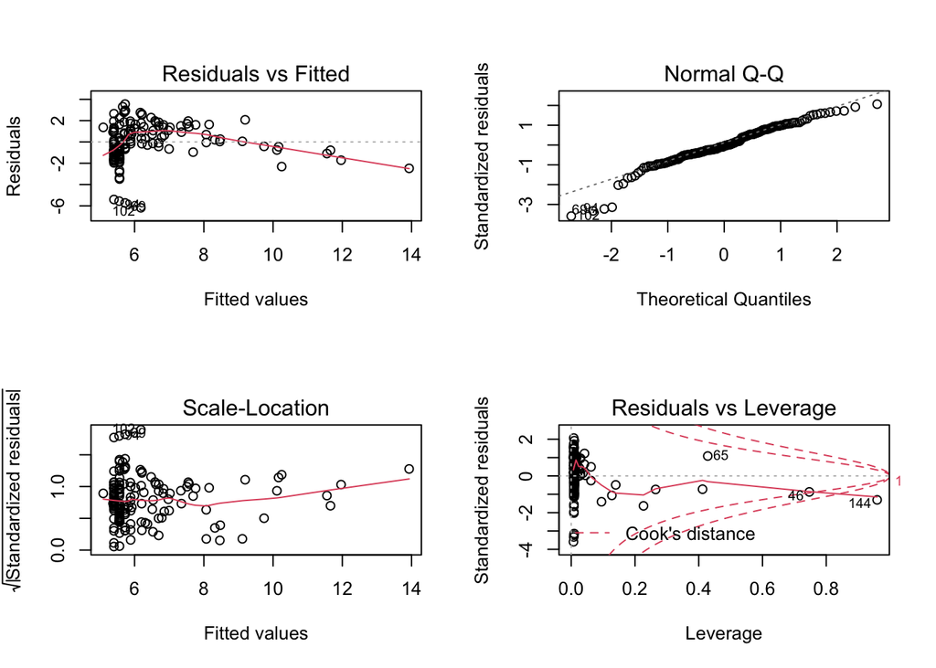

### 2. Data splitting

```
## [1] "There are 75 training and 74 validating/testing observations."
```

### 3. First-order model selection using best subsets criteria

### a. adjusted r squared

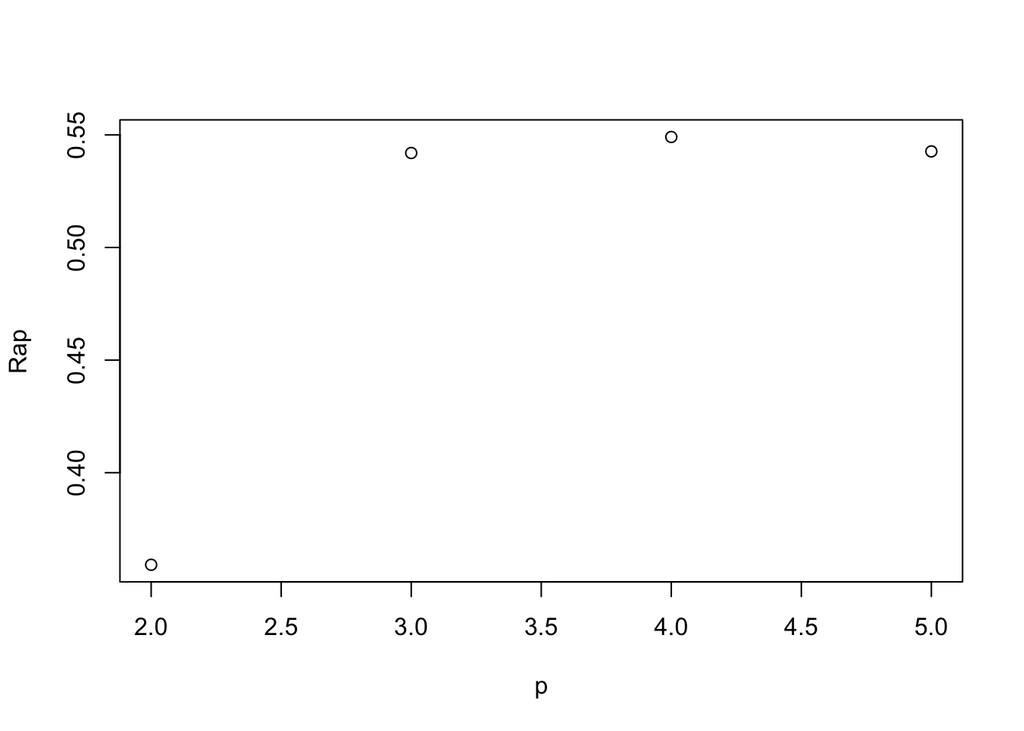

```
## [1] 3
```

```
##     (Intercept)           Union InspectionScope NumberInstances  PeopleExposure
##            TRUE            TRUE            TRUE            TRUE           FALSE
```

### b. Cp

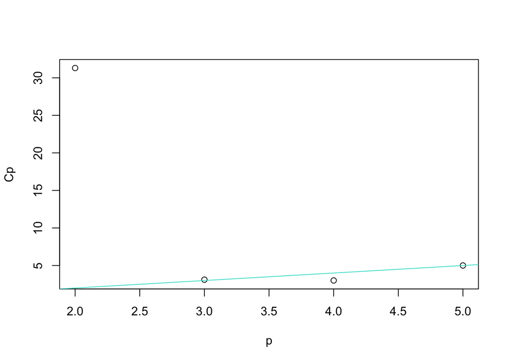

```
## 3
## 3
```

```
##     (Intercept)           Union InspectionScope NumberInstances  PeopleExposure
##            TRUE            TRUE            TRUE            TRUE           FALSE
```

```
## [1] 3
```

```
##     (Intercept)           Union InspectionScope NumberInstances  PeopleExposure
##            TRUE            TRUE            TRUE            TRUE           FALSE
```

### c. AIC

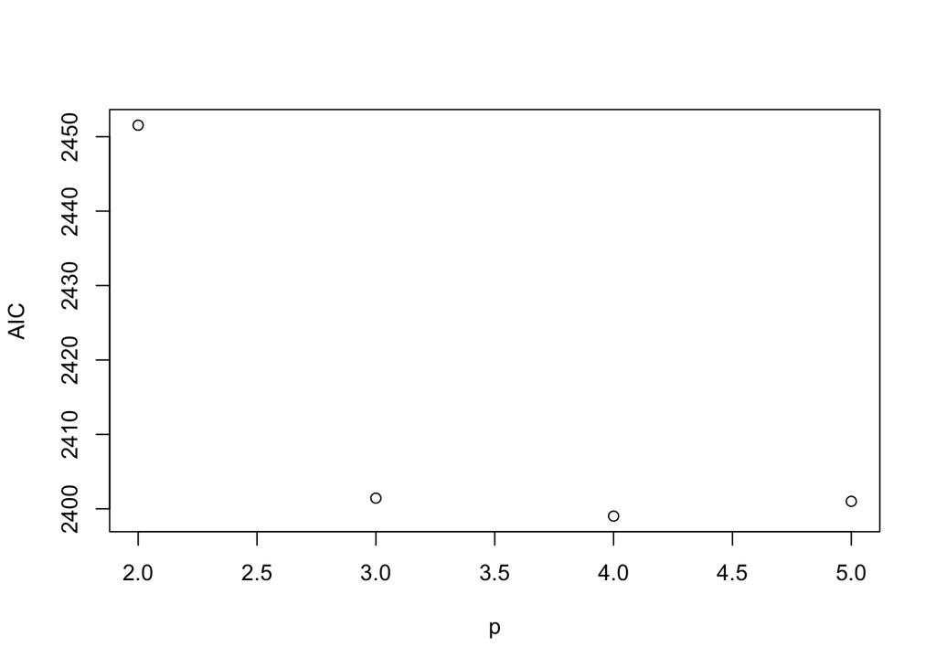

```
## 3
## 3
```

```
##     (Intercept)           Union InspectionScope NumberInstances  PeopleExposure
##            TRUE            TRUE            TRUE            TRUE           FALSE
```

### d. BIC

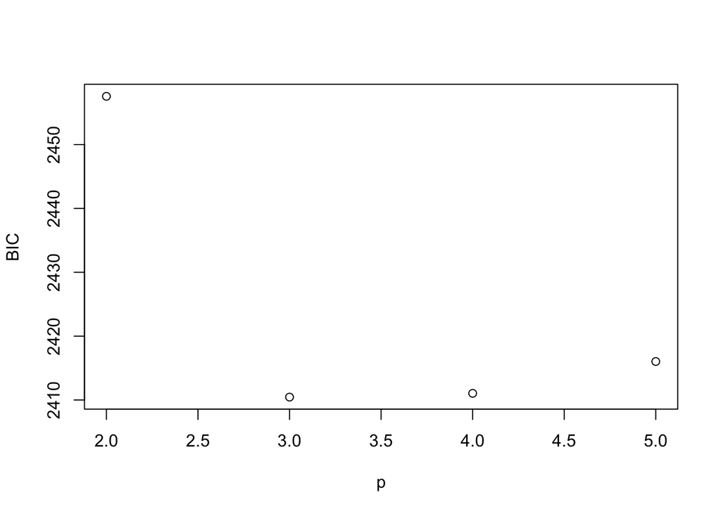

```
## 2
## 2
```

```
##     (Intercept)           Union InspectionScope NumberInstances  PeopleExposure
##            TRUE            TRUE            TRUE           FALSE           FALSE
```

### e. PRESS

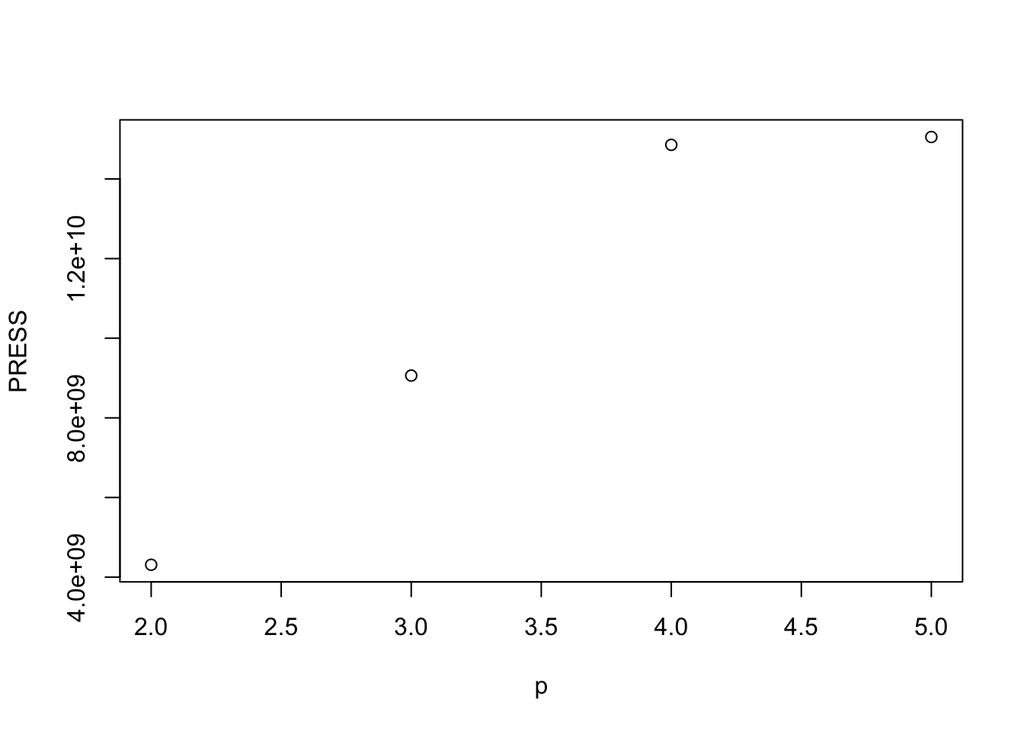

```
## [1] 1
```

```
##     (Intercept)           Union InspectionScope NumberInstances  PeopleExposure
##            TRUE            TRUE           FALSE           FALSE           FALSE
```

Most of the best criteria selected the model 2 and model 3. We will do model diagnostic to select the optimal one.

### b. 4. First-order model diagnostic

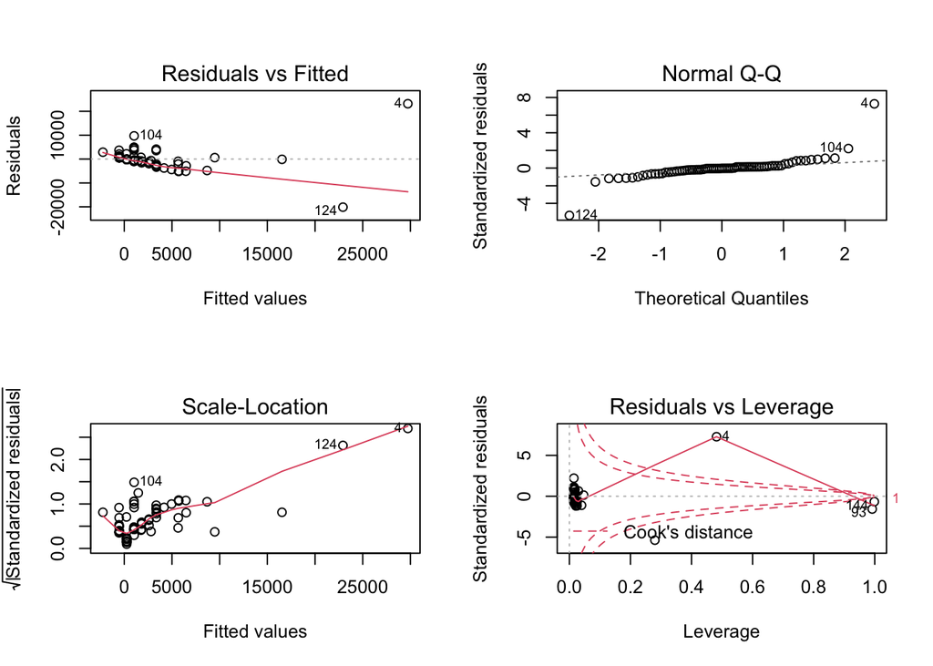

```
##
## Call:
## lm(formula = Y ~ ., data = data.frame(Xs[, temp]))
##
## Residuals:
##      Min       1Q   Median       3Q      Max
## -20134.5  -1092.4   -111.2    671.1  23173.4
##
## Coefficients:
##                 Estimate Std. Error t value Pr(>|t|)
## (Intercept)     -525.612    597.856  -0.879    0.382
## Union            784.732     86.229   9.101 1.53e-13 ***
## InspectionScope -565.065     99.922  -5.655 3.04e-07 ***
## NumberInstances   -5.920      4.052  -1.461    0.148
## ---
## Signif. codes:  0 '***' 0.001 '**' 0.01 '*' 0.05 '.' 0.1 ' ' 1
##
## Residual standard error: 4421 on 71 degrees of freedom
## Multiple R-squared:  0.5674, Adjusted R-squared:  0.5491
## F-statistic: 31.04 on 3 and 71 DF,  p-value: 6.256e-13
```

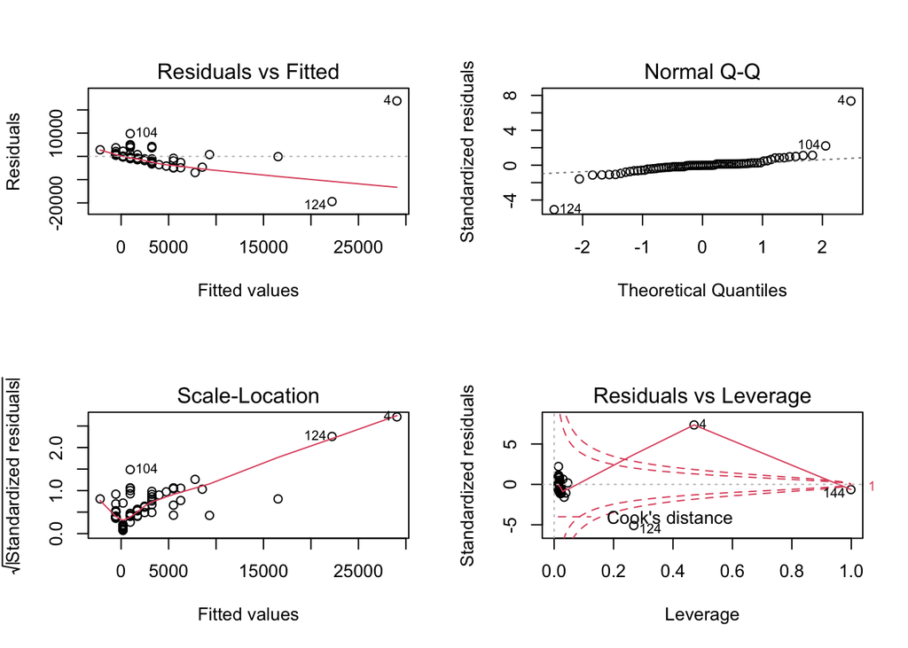

```
##
## Call:
## lm(formula = Y ~ ., data = data.frame(Xs[, temp]))
##
## Residuals:
##      Min       1Q   Median       3Q      Max
## -19426.9  -1152.5    -57.0    756.3  23849.1
##
## Coefficients:
##                 Estimate Std. Error t value Pr(>|t|)
## (Intercept)      -560.31     602.07  -0.931    0.355
## Union             759.34      85.12   8.921 2.94e-13 ***
## InspectionScope  -549.92     100.16  -5.490 5.70e-07 ***
## ---
## Signif. codes:  0 '***' 0.001 '**' 0.01 '*' 0.05 '.' 0.1 ' ' 1
##
## Residual standard error: 4456 on 72 degrees of freedom
## Multiple R-squared:  0.5543, Adjusted R-squared:  0.542
## F-statistic: 44.78 on 2 and 72 DF,  p-value: 2.312e-13
```

### b. 5. First-order with Two-way interaction model selection using stepwise algorithm

```
## Start:  AIC=1322.86
## Y ~ 1
##
##                   Df  Sum of Sq        RSS    AIC
## + Union            1 1179822816 2028236687 1293.5
## <none>                          3208059503 1322.9
## + InspectionScope  1  198231020 3009828483 1323.1
## + PeopleExposure   1   64631429 3143428074 1326.3
## + NumberInstances  1   10297495 3197762008 1327.6
##
## Step:  AIC=1293.48
## Y ~ Union
##
##                   Df  Sum of Sq        RSS    AIC
## + InspectionScope  1  598548929 1429687758 1272.2
## <none>                          2028236687 1293.5
## + NumberInstances  1   15105101 2013131586 1297.9
## + PeopleExposure   1    1433196 2026803491 1298.4
## - Union            1 1179822816 3208059503 1322.9
##
## Step:  AIC=1272.25
## Y ~ Union + InspectionScope
##
##                         Df  Sum of Sq        RSS    AIC
## <none>                                1429687758 1272.2
## + NumberInstances        1   41723944 1387963814 1275.0
## + Union:InspectionScope  1    8362377 1421325381 1276.8
## + PeopleExposure         1    7622886 1422064872 1276.9
## - InspectionScope        1  598548929 2028236687 1293.5
## - Union                  1 1580140725 3009828483 1323.1
```

```
##
## Call:
## lm(formula = Y ~ Union + InspectionScope, data = data.frame(Xs))
##
## Coefficients:
##     (Intercept)            Union  InspectionScope
##          -560.3            759.3           -549.9
```

There are 16 possible regression models of first-order with interaction, and the model with lowest AIC consist of the variable Union and InspectionScope only. That is similar result to our approach using best subset criteria.

### b. 6. First-order with Two-way interaction model diagnostic

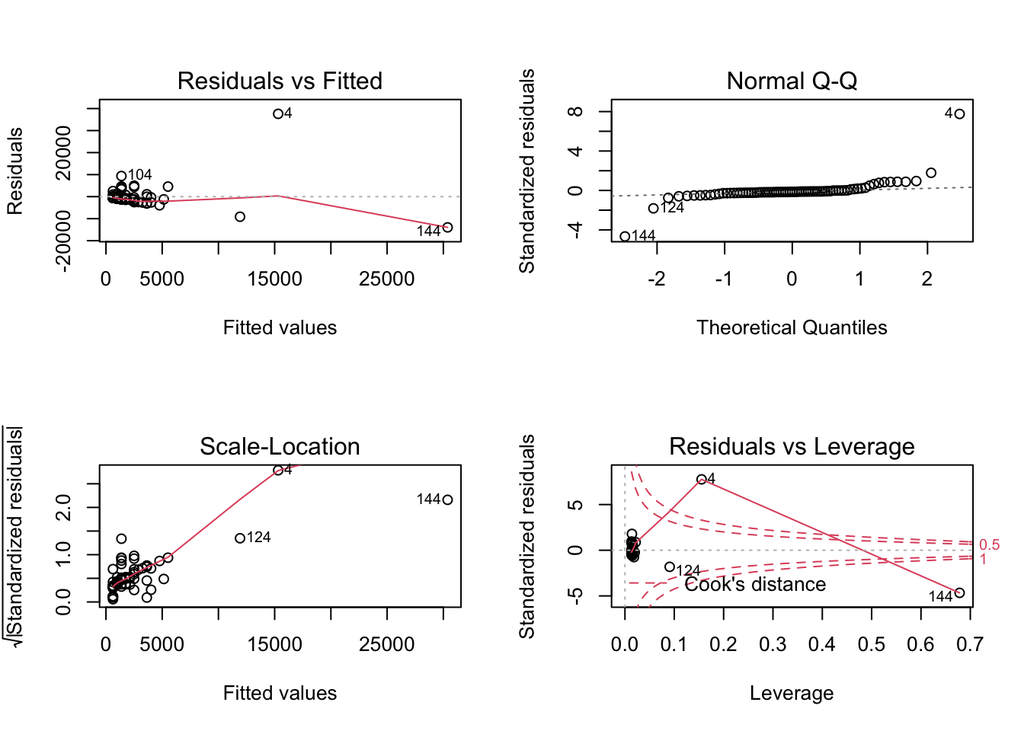

```
##
## Call:
## lm(formula = Y ~ ., data = data.frame(Xs))
##
## Residuals:
##    Min     1Q Median     3Q    Max
## -13955  -1229   -729    -54  37591
##
## Coefficients:
##             Estimate Std. Error t value Pr(>|t|)
## (Intercept)    621.3      665.1   0.934    0.353
## Xs             376.7       57.8   6.516  8.1e-09 ***
## ---
## Signif. codes:  0 '***' 0.001 '**' 0.01 '*' 0.05 '.' 0.1 ' ' 1
##
## Residual standard error: 5271 on 73 degrees of freedom
## Multiple R-squared:  0.3678, Adjusted R-squared:  0.3591
## F-statistic: 42.46 on 1 and 73 DF,  p-value: 8.101e-09
```

### b. 7. Model Validation

```
##
## Call:
## lm(formula = Y_val ~ ., data = data.frame(Xs_val))
##
## Residuals:
##    Min     1Q Median     3Q    Max
## -24381  -3050   1147   2089  55321
##
## Coefficients:
##             Estimate Std. Error t value Pr(>|t|)
## (Intercept)  -2039.4     1388.9  -1.468    0.146
## Xs_val         999.0      102.5   9.742  8.8e-15 ***
## ---
## Signif. codes:  0 '***' 0.001 '**' 0.01 '*' 0.05 '.' 0.1 ' ' 1
##
## Residual standard error: 9828 on 72 degrees of freedom
## Multiple R-squared:  0.5686, Adjusted R-squared:  0.5626
## F-statistic: 94.91 on 1 and 72 DF,  p-value: 8.797e-15
```